# Ever smoked

# 1 Description of DataSchema variable

The description of harmonised variable is the following:

- Short name: `ever_smoked`
- Variable label: `Ever smoked`
- Variable description: `Ever smoked. Any type of tobacco smoking`
- Domain: `Lifestyle and health behaviours`
- Value type: `categorical`
- Category coding:

| **Code** | **Category Label** |
| --- | --- |
| 0 | No |
| 1 | Yes |

- Category missings:

| **Code** | **Category Label** |
| --- | --- |
| 991 | CAPI/interviewer error |
| 992 | Impute |
| 993 | Disable to measure |
| 994 | Not attempt/not done |
| 995 | Does not answer |
| 996 | Not applicable |
| 997 | Refuse |
| 998 | Do not know |
| 999 | Missing |

# 2 Data process

## 2.1 England

### 2.1.1 Wave 1

#### 2.1.1.1 Study-specific variable description

| **Name** | `hesmk` |
| --- | --- |
| **Label** | `Have you ever smoked cigarettes?` |
| **Table name** | `wave_1_core_data_v3` |
| **Categories:** | `1 = Yes` `2 = No` |
| **Missings:** | `-1 = Not applicable` `-8 = Don't Know` `-9 = Refusal` |
| **Description** |  |

hesmk

| Sample size | Missing values |
| --- | --- |
| 12099 | 191 |

Category

|  | 1 | 2 |
| --- | --- | --- |
| Frequency | 7623.00 | 4285.00 |
| Percentage | 63.01 | 35.42 |

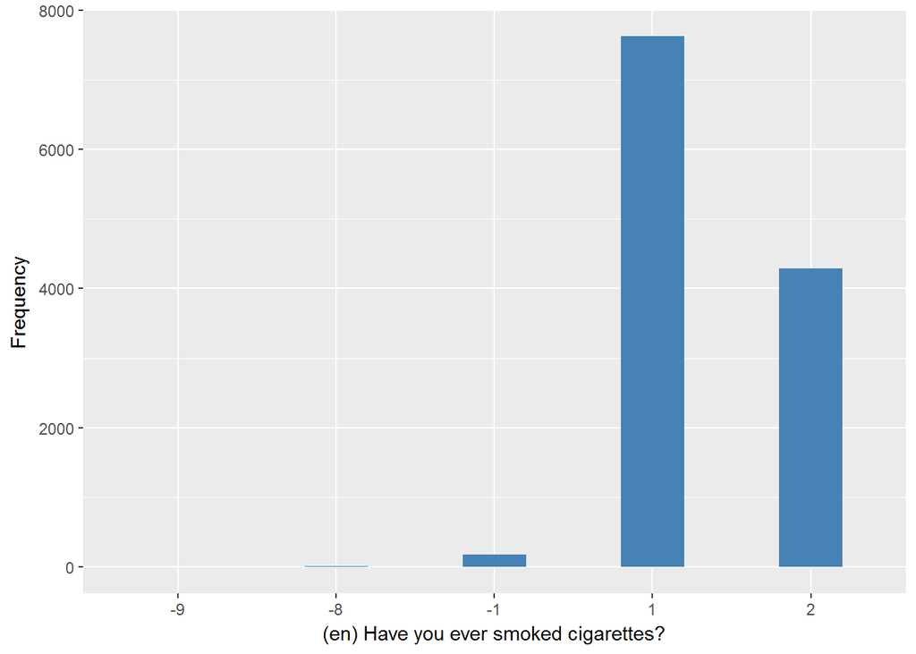

#### 2.1.1.2 Harmonisation algorithm

To compute `ever_smoked` from the study-specific variable it has to be recoded as follows:

- `2 into 0`
- `-1 into 996`
- `-8 into 998`
- `-9 into 997`

**R script:**

```r
ELSA_ds_w1 <- tibble(id = ELSA_w1$id)
ELSA_ds_w1$ever_smoked <- car::recode(ELSA_w1$hesmk, "2 = 0;-1 = 996;-8 = 998;-9 = 997 ")
```

#### 2.1.1.3 Statistical description of the new harmonised variable

Ever smoked

| Sample size | Missing values |
| --- | --- |
| 12099 | 191 |

Category

|  | 0 | 1 |
| --- | --- | --- |
| Frequency | 4285.00 | 7623.00 |
| Percentage | 35.42 | 63.01 |

Type of missing

|  | 991 | 992 | 993 | 994 | 995 | 996 | 997 | 998 | 999 | NA |
| --- | --- | --- | --- | --- | --- | --- | --- | --- | --- | --- |
| Frequency | 0 | 0 | 0 | 0 | 0 | 175.00 | 5.00 | 11.00 | 0 | 0 |
| Percentage | 0 | 0 | 0 | 0 | 0 | 1.45 | 0.04 | 0.09 | 0 | 0 |

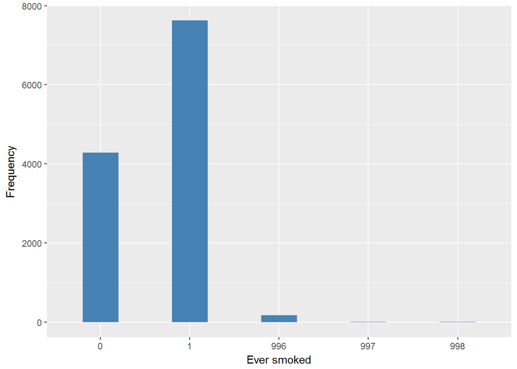

#### 2.1.1.4 Validation

### 2.1.2 Wave 2

#### 2.1.2.1 Study-specific variable description

| **Name** | `HeSmk` |
| --- | --- |
| **Label** | `Whether ever smoked cigarettes` |
| **Table name** | `wave_2_core_data_v4` |
| **Categories:** | `1 = Yes` `2 = No` |
| **Missings:** | `-1 = Not applicable` `-3 = Did not respond at w1 but were not asked` `-4 = Did respond at w1 but were asked` `-9 = Refusal` |
| **Description** |  |

HeSmk

| Sample size | Missing values |
| --- | --- |
| 9432 | 9247 |

Category

|  | 1 | 2 |
| --- | --- | --- |
| Frequency | 96.00 | 89.00 |
| Percentage | 1.02 | 0.94 |

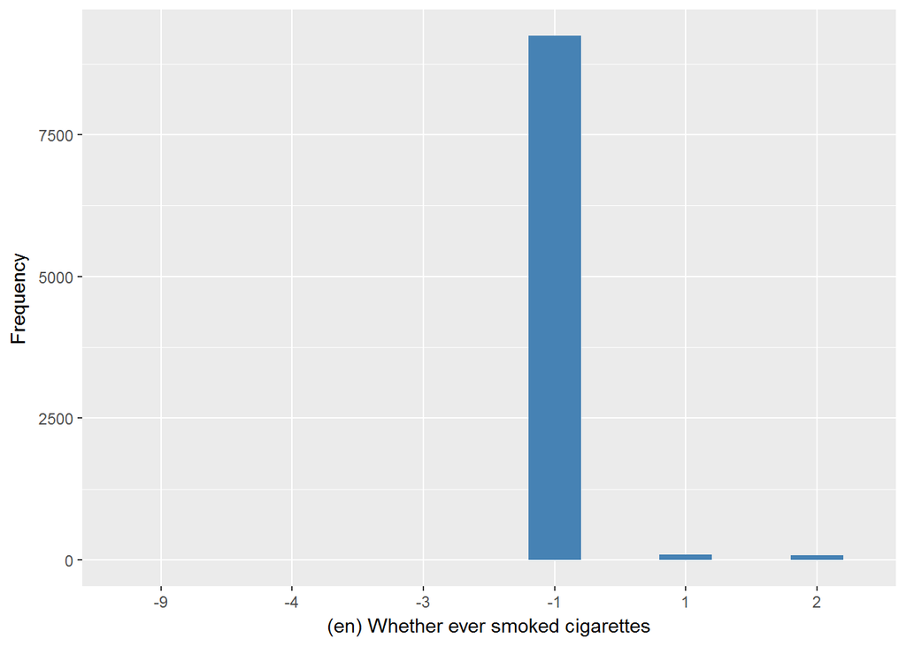

#### 2.1.2.2 Harmonisation algorithm

To compute `ever_smoked` from the study-specific variable it has to be recoded as follows:

- `2 into 0`
- `-1 into 996`
- `-3 into 999`
- `-4 into 999`
- `-9 into 997`

**R script:**

```r
ELSA_ds_w2 <- tibble(id = ELSA_w2$id)
ELSA_ds_w2$ever_smoked <- car::recode(ELSA_w2$HeSmk, "2 = 0;-1 = 996;-3 = 999;-4 = 999;-9 = 997 ")
```

#### 2.1.2.3 Statistical description of the new harmonised variable

Ever smoked

| Sample size | Missing values |
| --- | --- |
| 9432 | 9247 |

Category

|  | 0 | 1 |
| --- | --- | --- |
| Frequency | 89.00 | 96.00 |
| Percentage | 0.94 | 1.02 |

Type of missing

|  | 991 | 992 | 993 | 994 | 995 | 996 | 997 | 998 | 999 | NA |
| --- | --- | --- | --- | --- | --- | --- | --- | --- | --- | --- |
| Frequency | 0 | 0 | 0 | 0 | 0 | 9242.00 | 1.00 | 0 | 4.00 | 0 |
| Percentage | 0 | 0 | 0 | 0 | 0 | 97.99 | 0.01 | 0 | 0.04 | 0 |

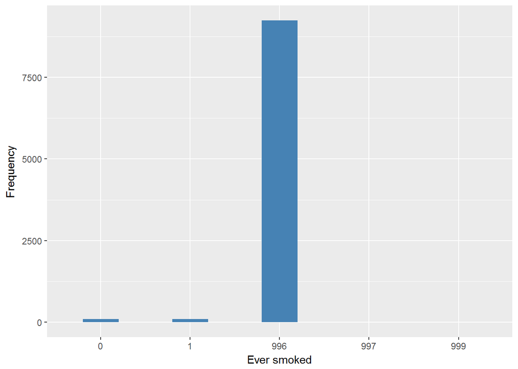

#### 2.1.2.4 Validation

### 2.1.3 Wave 3

#### 2.1.3.1 Study-specific variable description

| **Name** | `hesmk` |
| --- | --- |
| **Label** | `Whether ever smoked cigarettes` |
| **Table name** | `wave_3_elsa_data_v4` |
| **Categories:** | `1 = Yes` `2 = No` |
| **Missings:** | ``-1 = Not applicable` `-8 = Don't Know` |
| **Description** |  |

hesmk

| Sample size | Missing values |
| --- | --- |
| 9771 | 8030 |

Category

|  | 1 | 2 |
| --- | --- | --- |
| Frequency | 978.00 | 763.00 |
| Percentage | 10.01 | 7.81 |

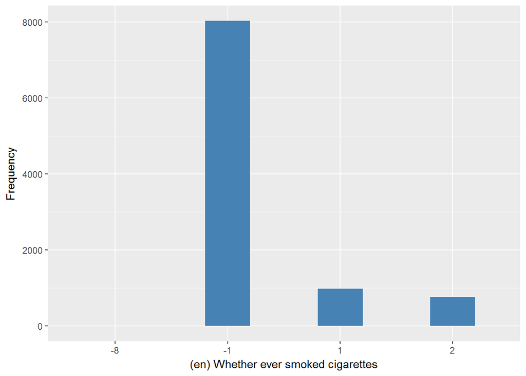

#### 2.1.3.2 Harmonisation algorithm

To compute `ever_smoked` from the study-specific variable it has to be recoded as follows:

- `2 into 0`
- `-1 into 996`
- `-8 into 998`

**R script:**

```r
ELSA_ds_w3 <- tibble(id = ELSA_w3$id)
ELSA_ds_w3$ever_smoked <- car::recode(ELSA_w3$hesmk, "2 = 0;-1 = 996;-8 = 998 ")
```

#### 2.1.3.3 Statistical description of the new harmonised variable

Ever smoked

| Sample size | Missing values |
| --- | --- |
| 9771 | 8030 |

Category

|  | 0 | 1 |
| --- | --- | --- |
| Frequency | 763.00 | 978.00 |
| Percentage | 7.81 | 10.01 |

Type of missing

|  | 991 | 992 | 993 | 994 | 995 | 996 | 997 | 998 | 999 | NA |
| --- | --- | --- | --- | --- | --- | --- | --- | --- | --- | --- |
| Frequency | 0 | 0 | 0 | 0 | 0 | 8029.00 | 0 | 1.00 | 0 | 0 |
| Percentage | 0 | 0 | 0 | 0 | 0 | 82.17 | 0 | 0.01 | 0 | 0 |

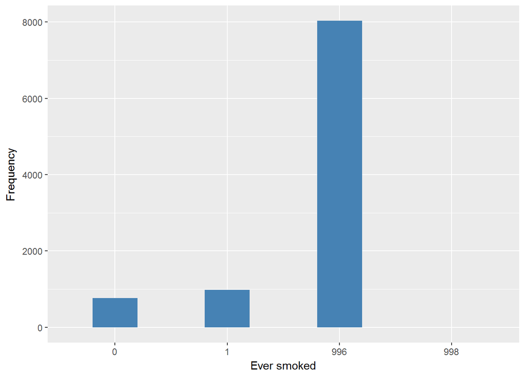

#### 2.1.3.4 Validation

### 2.1.4 Wave 4

#### 2.1.4.1 Study-specific variable description

| **Name** | `hesmk` |
| --- | --- |
| **Label** | `Whether ever smoked cigarettes` |
| **Table name** | `wave_4_elsa_data_v3` |
| **Categories:** | `1 = Yes` `2 = No` |
| **Missings:** | `-9 = Refusal` `-8 = Don't Know` `-2 = Capi/Interview Error` `-1 = Item not applicable` |
| **Description** |  |

hesmk

| Sample size | Missing values |
| --- | --- |
| 11050 | 8495 |

Category

|  | 1 | 2 |
| --- | --- | --- |
| Frequency | 1489.00 | 1066.00 |
| Percentage | 13.48 | 9.65 |

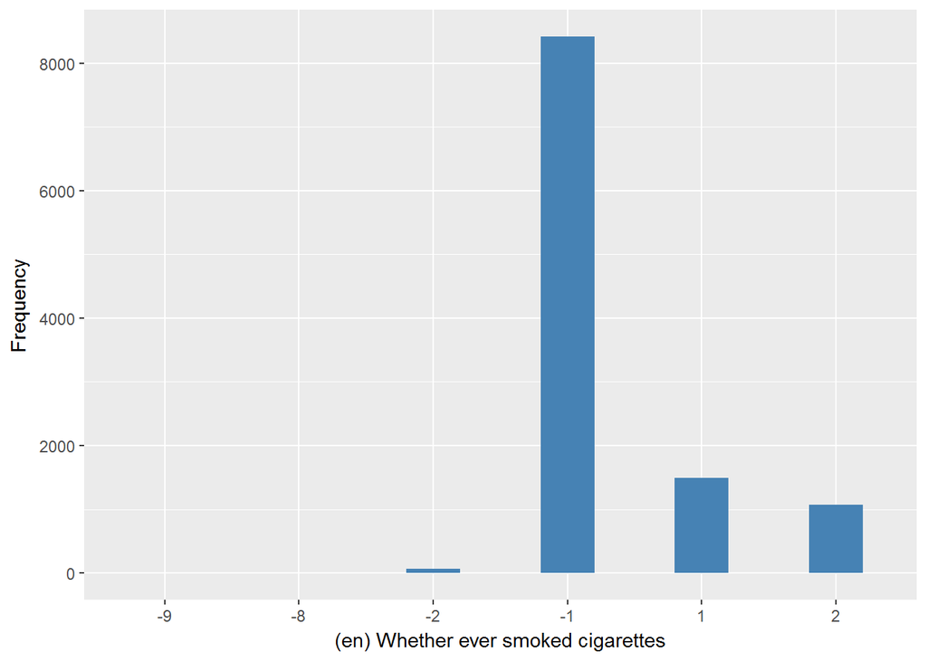

#### 2.1.4.2 Harmonisation algorithm

To compute `ever_smoked` from the study-specific variable it has to be recoded as follows:

- `2 into 0`
- `-1 into 996`
- `-2 into 991`
- `-8 into 998`
- `-9 into 997`

**R script:**

```r
ELSA_ds_w4 <- tibble(id = ELSA_w4$id)
ELSA_ds_w4$ever_smoked <- car::recode(ELSA_w4$hesmk, "2 = 0;-1 = 996;-2 = 991;-8 = 998;-9 = 997 ")
```

#### 2.1.4.3 Statistical description of the new harmonised variable

Ever smoked

| Sample size | Missing values |
| --- | --- |
| 11050 | 8495 |

Category

|  | 0 | 1 |
| --- | --- | --- |
| Frequency | 1066.00 | 1489.00 |
| Percentage | 9.65 | 13.48 |

Type of missing

|  | 991 | 992 | 993 | 994 | 995 | 996 | 997 | 998 | 999 | NA |
| --- | --- | --- | --- | --- | --- | --- | --- | --- | --- | --- |
| Frequency | 72.00 | 0 | 0 | 0 | 0 | 8417.00 | 4.00 | 2.00 | 0 | 0 |
| Percentage | 0.65 | 0 | 0 | 0 | 0 | 76.17 | 0.04 | 0.02 | 0 | 0 |

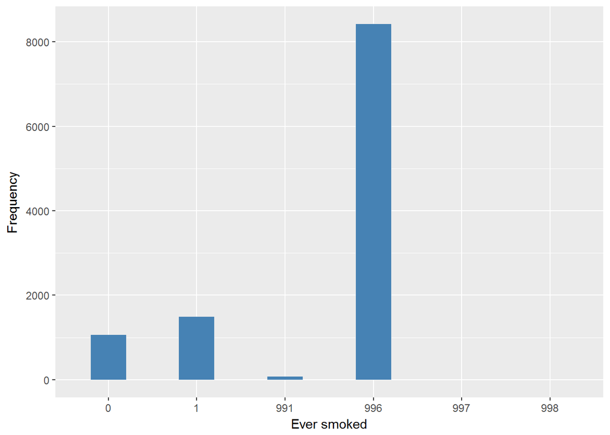

#### 2.1.4.4 Validation

### 2.1.5 Wave 5

#### 2.1.5.1 Study-specific variable description

| **Name** | `hesmk` |
| --- | --- |
| **Label** | `Whether ever smoked cigarettes` |
| **Table name** | `wave_5_elsa_data_v4` |
| **Categories:** | `1 = Yes` `2 = No` |
| **Missings:** | `-1 = Item not applicable` `-8 = Don't Know` `-9 = Refusal` |
| **Description** |  |

hesmk

| Sample size | Missing values |
| --- | --- |
| 10274 | 6197 |

Category

|  | 1 | 2 |
| --- | --- | --- |
| Frequency | 407.00 | 3670.00 |
| Percentage | 3.96 | 35.72 |

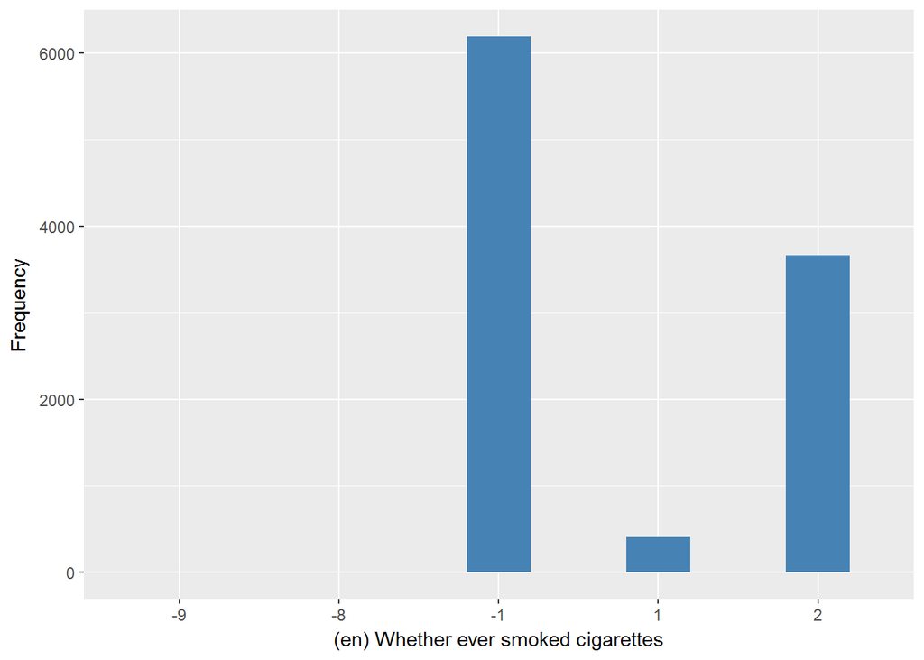

#### 2.1.5.2 Harmonisation algorithm

To compute `ever_smoked` from the study-specific variable it has to be recoded as follows:

- `2 into 0`
- `-1 into 996`
- `-8 into 998`
- `-9 into 997`

**R script:**

```r
ELSA_ds_w5 <- tibble(id = ELSA_w5$id)
ELSA_ds_w5$ever_smoked <- car::recode(ELSA_w5$hesmk, "2 = 0;-1 = 996;-8 = 998;-9 = 997 ")
```

#### 2.1.5.3 Statistical description of the new harmonised variable

Ever smoked

| Sample size | Missing values |
| --- | --- |
| 10274 | 6197 |

Category

|  | 0 | 1 |
| --- | --- | --- |
| Frequency | 3670.00 | 407.00 |
| Percentage | 35.72 | 3.96 |

Type of missing

|  | 991 | 992 | 993 | 994 | 995 | 996 | 997 | 998 | 999 | NA |
| --- | --- | --- | --- | --- | --- | --- | --- | --- | --- | --- |
| Frequency | 0 | 0 | 0 | 0 | 0 | 6194.00 | 2.00 | 1.00 | 0 | 0 |
| Percentage | 0 | 0 | 0 | 0 | 0 | 60.29 | 0.02 | 0.01 | 0 | 0 |

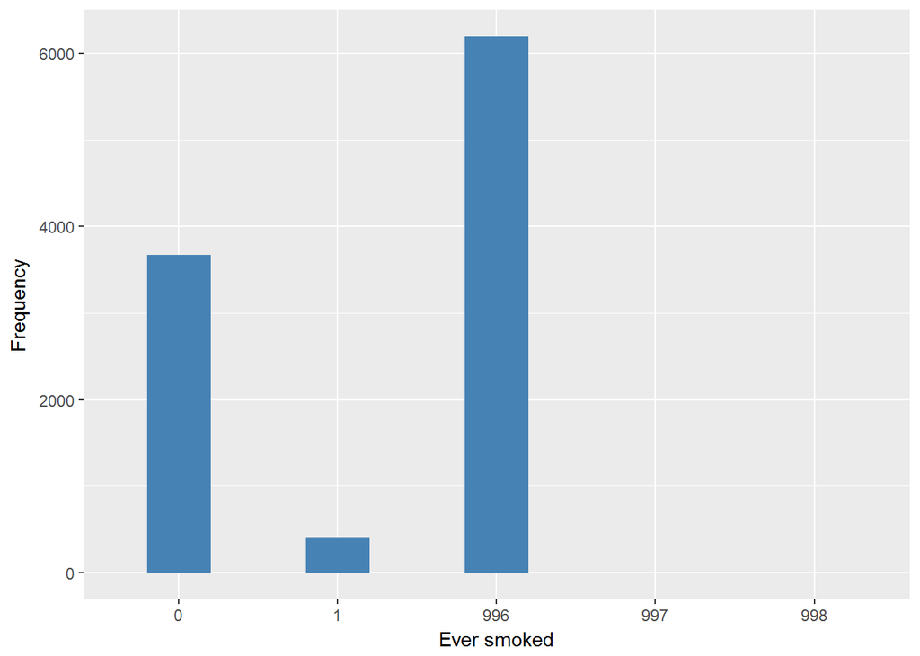

#### 2.1.5.4 Validation

### 2.1.6 Wave 6

#### 2.1.6.1 Study-specific variable description

| **Name** | `HeSmk` |
| --- | --- |
| **Label** | `Whether ever smoked cigarettes` |
| **Table name** | `wave_6_elsa_data_v2` |
| **Categories:** | `1 = Yes` `2 = No` |
| **Missings:** | `-1 = Item not applicable` `-8 = Don't Know` `-9 = Refusal` |
| **Description** |  |

HeSmk

| Sample size | Missing values |
| --- | --- |
| 10601 | 6008 |

Category

|  | 1 | 2 |
| --- | --- | --- |
| Frequency | 815.00 | 3778.00 |
| Percentage | 7.69 | 35.64 |

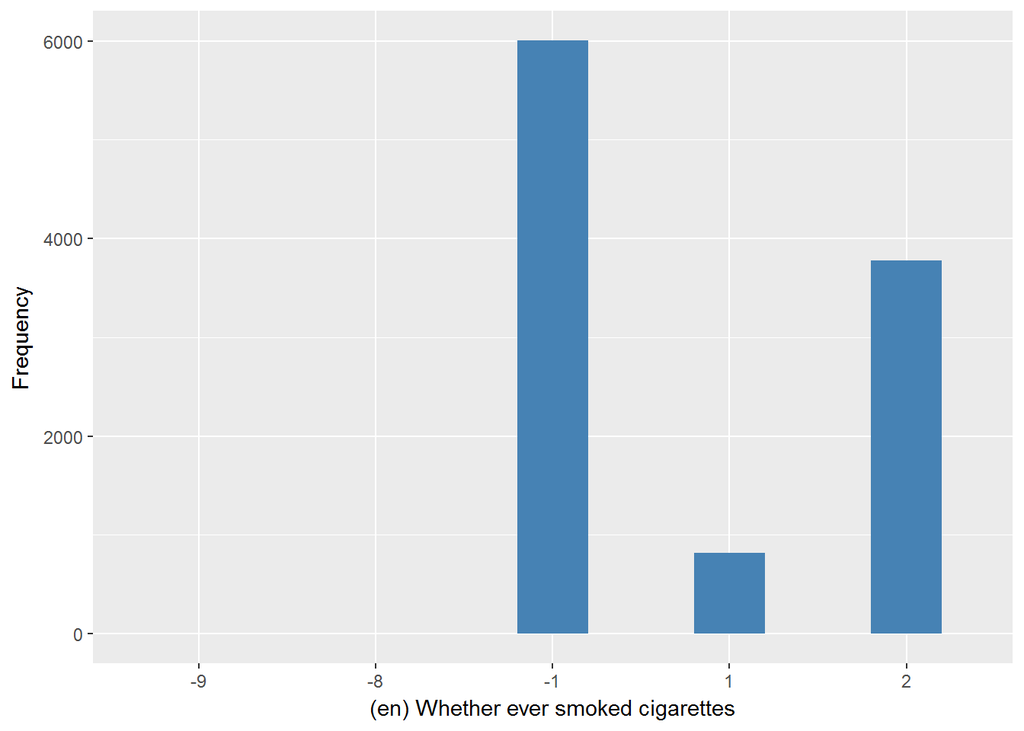

#### 2.1.6.2 Harmonisation algorithm

To compute `ever_smoked` from the study-specific variable it has to be recoded as follows:

- `2 into 0`
- `-1 into 996`
- `-8 into 998`
- `-9 into 997`

**R script:**

```r
ELSA_ds_w6 <- tibble(id = ELSA_w6$id)
ELSA_ds_w6$ever_smoked <- car::recode(ELSA_w6$HeSmk, "2 = 0;-1 = 996;-8 = 998;-9 = 997 ")
```

#### 2.1.6.3 Statistical description of the new harmonised variable

Ever smoked

| Sample size | Missing values |
| --- | --- |
| 10601 | 6008 |

Category

|  | 0 | 1 |
| --- | --- | --- |
| Frequency | 3778.00 | 815.00 |
| Percentage | 35.64 | 7.69 |

Type of missing

|  | 991 | 992 | 993 | 994 | 995 | 996 | 997 | 998 | 999 | NA |
| --- | --- | --- | --- | --- | --- | --- | --- | --- | --- | --- |
| Frequency | 0 | 0 | 0 | 0 | 0 | 6005.00 | 2.00 | 1.00 | 0 | 0 |
| Percentage | 0 | 0 | 0 | 0 | 0 | 56.65 | 0.02 | 0.01 | 0 | 0 |

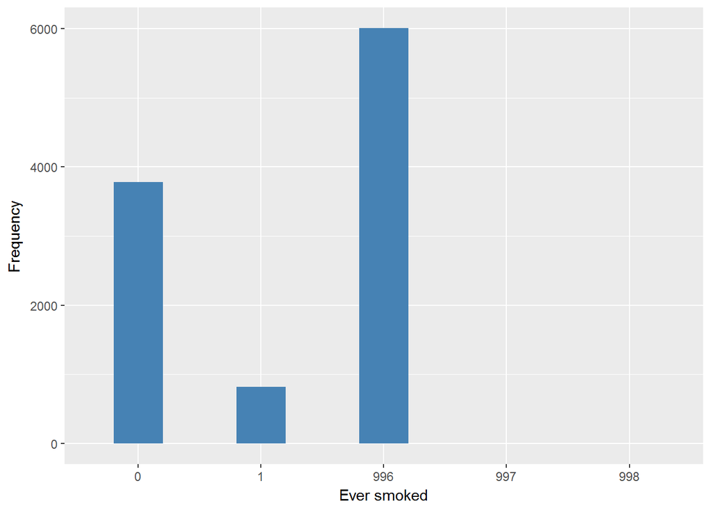

#### 2.1.6.4 Validation

### 2.1.7 Wave 7

#### 2.1.7.1 Study-specific variable description

| **Name** | `HeSmk` |
| --- | --- |
| **Label** | `Whether ever smoked cigarettes` |
| **Table name** | `wave_7_elsa_data` |
| **Categories:** | `1 = Yes` `2 = No` |
| **Missings:** | `-1 = Item not applicable` `-8 = Don't Know` `-9 = Refusal` |
| **Description** |  |

HeSmk

| Sample size | Missing values |
| --- | --- |
| 9666 | 5882 |

Category

|  | 1 | 2 |
| --- | --- | --- |
| Frequency | 370.00 | 3414.00 |
| Percentage | 3.83 | 35.32 |

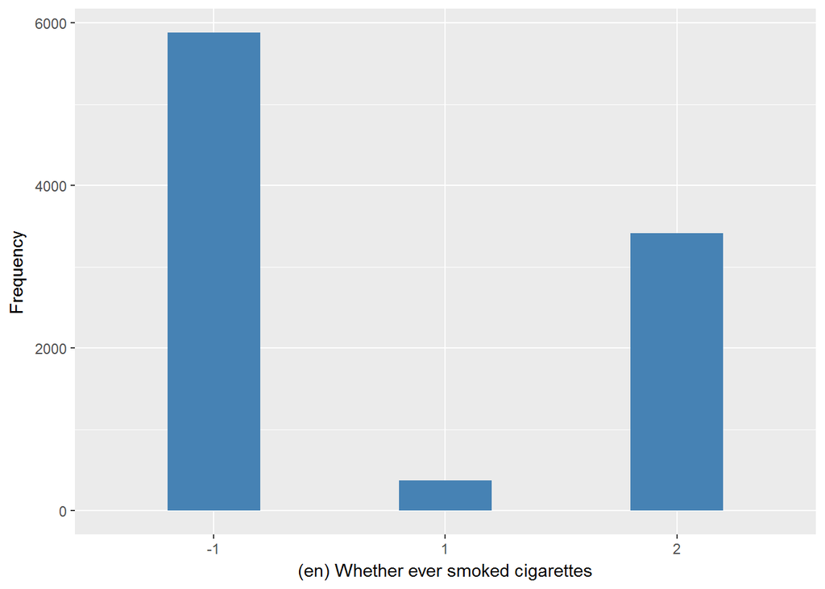

#### 2.1.7.2 Harmonisation algorithm

To compute `ever_smoked` from the study-specific variable it has to be recoded as follows:

- `2 into 0`
- `-1 into 996`
- `-8 into 998`
- `-9 into 997`

**R script:**

```r
ELSA_ds_w7 <- tibble(id = ELSA_w7$id)
ELSA_ds_w7$ever_smoked <- car::recode(ELSA_w7$HeSmk, "2 = 0;-1 = 996;-8 = 998;-9 = 997 ")
```

#### 2.1.7.3 Statistical description of the new harmonised variable

Ever smoked

| Sample size | Missing values |
| --- | --- |
| 9666 | 5882 |

Category

|  | 0 | 1 |
| --- | --- | --- |
| Frequency | 3414.00 | 370.00 |
| Percentage | 35.32 | 3.83 |

Type of missing

|  | 991 | 992 | 993 | 994 | 995 | 996 | 997 | 998 | 999 | NA |
| --- | --- | --- | --- | --- | --- | --- | --- | --- | --- | --- |
| Frequency | 0 | 0 | 0 | 0 | 0 | 5882.00 | 0 | 0 | 0 | 0 |
| Percentage | 0 | 0 | 0 | 0 | 0 | 60.85 | 0 | 0 | 0 | 0 |

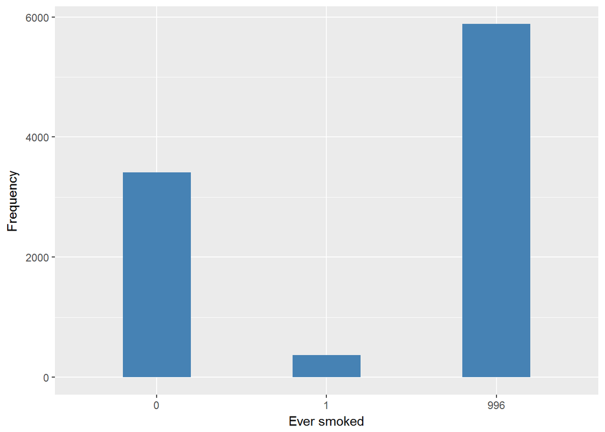

#### 2.1.7.4 Validation

## 2.2 Summary of descriptive statistics of the harmonised variable accross populations and waves

Two tables are generated:

1. Percentages of categories in each harmonised variable.
2. Frequencies and percentages of individuals with different trajectories. To avoid too large table, Only trajectories with percentages larger than 0.3 are shown.

```r
t.hds <- frq(l.hds[[1]][2])[[1]][, c(1, 2)]
for (i in seq_along(l.hds)) {
    t.hds[2 + i] <- frq(l.hds[[i]][2])[[1]][, 4]
}
t.hds[13, ] <- c("n", "sample size", sapply(l.hds, function(wave) length(wave[[1]])))
names(t.hds) <- c("val", "label", names(l.hds))
kable(t.hds)
```

| val | label | w1 | w2 | w3 | w4 | w5 | w6 | w7 |
| --- | --- | --- | --- | --- | --- | --- | --- | --- |
| 0 | No | 35.42 | 0.94 | 7.81 | 9.65 | 35.72 | 35.64 | 35.32 |
| 1 | Yes | 63.01 | 1.02 | 10.01 | 13.48 | 3.96 | 7.69 | 3.83 |
| 991 | CAPI interviewer error | 0 | 0 | 0 | 0.65 | 0 | 0 | 0 |
| 992 | Impute | 0 | 0 | 0 | 0 | 0 | 0 | 0 |
| 993 | Disable to measure | 0 | 0 | 0 | 0 | 0 | 0 | 0 |
| 994 | Not attempt not done | 0 | 0 | 0 | 0 | 0 | 0 | 0 |
| 995 | Does not answer | 0 | 0 | 0 | 0 | 0 | 0 | 0 |
| 996 | Not applicable | 1.45 | 97.99 | 82.17 | 76.17 | 60.29 | 56.65 | 60.85 |
| 997 | Refuse | 0.04 | 0.01 | 0 | 0.04 | 0.02 | 0.02 | 0 |
| 998 | Do not know | 0.09 | 0 | 0.01 | 0.02 | 0.01 | 0.01 | 0 |
| 999 | Missing | 0 | 0.04 | 0 | 0 | 0 | 0 | 0 |
| NA | NA | 0 | 0 | 0 | 0 | 0 | 0 | 0 |
| n | sample size | 12099 | 9432 | 9771 | 11050 | 10274 | 10601 | 9666 |

```r
dbb <- get(paste0("ELSA_m_ds_", names(l.hds)[1]))[, c("id", "ever_smoked")]
for (ind in 2:length(l.hds)) {
    dbb <- merge(dbb, get(paste0("ELSA_m_ds_", names(l.hds)[ind]))[, c("id",
        "ever_smoked")], by = "id", suffixes = c("", paste0(".", names(l.hds)[ind])),
        all = T)
}
names(dbb) <- c("id", names(l.hds))

v.dbb <- dbb[, 2]
for (ind in 2:length(l.hds)) {
    v.dbb <- paste(v.dbb, dbb[, ind + 1], sep = "")
}
f.dbb <- frq(v.dbb)[[1]][, c(1, 2, 4)]
kable(f.dbb[f.dbb[, 3] >= 0.3, ])
```

|  | val | frq | raw.prc |
| --- | --- | --- | --- |
| 5 | 0NANANA000 | 1613 | 8.72 |
| 7 | 0NANANA00NA | 269 | 1.45 |
| 8 | 0NANANA01NA | 72 | 0.39 |
| 11 | 0NANANA0NANA | 223 | 1.21 |
| 14 | 0NANANA1NANA | 151 | 0.82 |
| 20 | 0NANANANANANA | 1755 | 9.49 |
| 33 | 1NANANANANANA | 7499 | 40.56 |
| 46 | NA1NANANANANA | 94 | 0.51 |
| 48 | NANA0NA000 | 350 | 1.89 |
| 50 | NANA0NA00NA | 65 | 0.35 |
| 60 | NANA0NANANANA | 200 | 1.08 |
| 67 | NANA1NANANANA | 953 | 5.15 |
| 68 | NANANA0000 | 593 | 3.21 |
| 70 | NANANA000NA | 88 | 0.48 |
| 73 | NANANA00NANA | 72 | 0.39 |
| 80 | NANANA0NANANA | 139 | 0.75 |
| 89 | NANANA1NANANA | 1427 | 7.72 |
| 99 | NANANANA1NANA | 70 | 0.38 |
| 100 | NANANANANA00 | 390 | 2.11 |
| 102 | NANANANANA0NA | 107 | 0.58 |
| 104 | NANANANANA1NA | 607 | 3.28 |
| 105 | NANANANANANA0 | 233 | 1.26 |
| 106 | NANANANANANA1 | 237 | 1.28 |
| 107 | NANANANANANANA | 401 | 2.17 |

# 3 Quality estimation